# Analysis of contextualized sensorimotor norms

### Comparing AIC

```r
# ============================================================
# 2. For each model/layer: compute R² and AIC, difference from SM baseline
# ============================================================

relatedness_results <- df_merged %>%
  group_by(Model, Layer, n_params, Multilingual) %>%
  summarize(
    # Sensorimotor only
    r2_sm = {
      model <- lm(mean_relatedness ~ sensorimotor_distance)
      summary(model)$r.squared
    },
    aic_sm = {
      model <- lm(mean_relatedness ~ sensorimotor_distance)
      AIC(model)
    },
    # BERT only
    r2_bert = {
      model <- lm(mean_relatedness ~ Distance)
      summary(model)$r.squared
    },
    aic_bert = {
      model <- lm(mean_relatedness ~ Distance)
      AIC(model)
    },
    # Combined
    r2_combined = {
      model <- lm(mean_relatedness ~ Distance + sensorimotor_distance)
      summary(model)$r.squared
    },
    aic_combined = {
      model <- lm(mean_relatedness ~ Distance + sensorimotor_distance)
      AIC(model)
    },
    .groups = "drop"
  ) %>%
  mutate(
    aic_bert_vs_sm = aic_bert - aic_sm,
    aic_combined_vs_sm = aic_sm - aic_combined,
    aic_combined_vs_dist = aic_bert - aic_combined
  )

# ============================================================
# 3. Best layer per model
# ============================================================

best_layers <- relatedness_results %>%
  group_by(Model, n_params, Multilingual) %>%
  slice_max(r2_bert, n = 1) %>%
  select(Model, Layer, n_params, Multilingual,
         # r2_sm, r2_bert, r2_combined,
         aic_bert_vs_sm, aic_sm, aic_bert, aic_combined,
         aic_combined_vs_sm, aic_combined_vs_dist)

print(best_layers)
```

```
## # A tibble: 12 × 10
## # Groups:   Model, n_params, Multilingual [12]
##    Model Layer n_params Multilingual aic_bert_vs_sm aic_sm aic_bert aic_combined
##    <chr> <dbl>    <dbl> <chr>                 <dbl>  <dbl>    <dbl>        <dbl>
##  1 ALBE…     9   1.17e7 Monolingual          111.    2135.    2246.        2053.
##  2 ALBE…    12   1.17e7 Monolingual            4.57  2135.    2139.        1997.
##  3 ALBE…    14   1.77e7 Monolingual            7.41  2135.    2142.        2002.
##  4 ALBE…    15   5.87e7 Monolingual         -140.    2135.    1995.        1878.
##  5 ALBE…     8   2.23e8 Monolingual         -234.    2135.    1901.        1790.
##  6 BERT…    12   1.08e8 Monolingual          -96.8   2135.    2038.        1911.
##  7 BERT…    12   1.09e8 Monolingual         -175.    2135.    1960.        1855.
##  8 Dist…     6   6.64e7 Monolingual          -79.2   2135.    2056.        1937.
##  9 Mult…    12   1.78e8 Multilingual          90.7   2135.    2225.        2062.
## 10 RoBE…    11   1.25e8 Monolingual         -117.    2135.    2018.        1899.
## 11 RoBE…    22   3.55e8 Monolingual         -291.    2135.    1844.        1759.
## 12 XLM-…     9   2.78e8 Multilingual         143.    2135.    2277.        2088.
## # ℹ 2 more variables: aic_combined_vs_sm <dbl>, aic_combined_vs_dist <dbl>
```

```r
best_layers %>%
  ungroup() %>%
  select(Model, aic_bert, aic_combined) %>%
  mutate(across(starts_with("aic"), round)) %>%
  kbl(col.names = c("Model", "Distributional", "Hybrid"),
      format = "latex",
      booktabs = TRUE,
      caption = "AIC values for predicting relatedness judgments using Distributional Distance alone or both Distributional Distance and Sensorimotor Distance (AIC for Sensorimotor Distance was 2134.78.)",
      label = "aic") %>%
  kable_styling(latex_options = "hold_position")
```

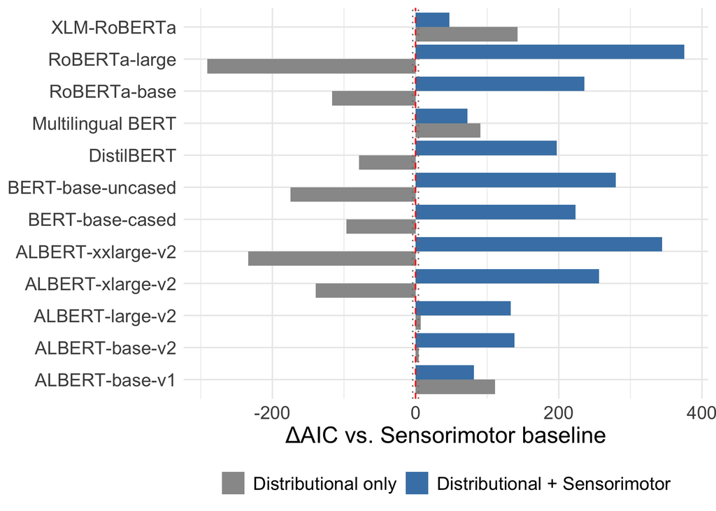

```r
best_layers %>%
  select(Model, aic_bert_vs_sm, aic_combined_vs_sm) %>%
  pivot_longer(cols = c(aic_bert_vs_sm, aic_combined_vs_sm),
               names_to = "type", values_to = "aic_diff") %>%
  mutate(type = ifelse(type == "aic_bert_vs_sm", "Distributional only", "Distributional + Sensorimotor"),
         type = factor(type, levels = c("Distributional only", "Distributional + Sensorimotor")),
         Model = fct_reorder(Model, aic_diff)) %>%
  ggplot(aes(x = aic_diff, y = Model, fill = type)) +
  geom_col(position = "dodge") +
  geom_vline(xintercept = 0, linetype = "dashed", color = "red") +
  geom_vline(xintercept = 4, linetype = "dotted", color = "gray50") +
  geom_vline(xintercept = -4, linetype = "dotted", color = "gray50") +
  labs(x = "ΔAIC vs. Sensorimotor baseline",
       y = NULL,
       fill = NULL) +
  scale_fill_manual(values = c("Distributional only" = "gray60",
                                "Distributional + Sensorimotor" = "steelblue")) +
  theme_minimal() +
  theme(text = element_text(size = 16),
        legend.position = "bottom")
```

```r
# ============================================================
# 7. Summary
# ============================================================

best_layers %>%
  ungroup() %>%
  mutate(dist_better_than_sm = aic_bert_vs_sm < -4,
         hybrid_better_than_sm = aic_combined_vs_sm > 4,
         hybrid_better_than_dist = aic_combined_vs_dist > 4) %>%
  summarise(mean(dist_better_than_sm),
            mean(hybrid_better_than_sm),
            mean(hybrid_better_than_dist))
```

```
## # A tibble: 1 × 3
##   `mean(dist_better_than_sm)` mean(hybrid_better_than_s…¹ mean(hybrid_better_t…²
##                         <dbl>                       <dbl>                  <dbl>
## 1                       0.583                           1                      1
## # ℹ abbreviated names: ¹`mean(hybrid_better_than_sm)`,
## #   ²`mean(hybrid_better_than_dist)`
```

```r
### Visualize raw AIC
aic_summary_full <- best_layers %>%
  select(Model, Layer, aic_sm, aic_bert, aic_combined) %>%
  pivot_longer(cols = c(aic_sm, aic_bert, aic_combined),
               names_to = "type", values_to = "aic") %>%
  mutate(type = case_when(
    type == "aic_sm" ~ "Sensorimotor",
    type == "aic_bert" ~ "Distributional",
    type == "aic_combined" ~ "Hybrid"
  ),
  type = factor(type, levels = c("Sensorimotor", "Distributional", "Hybrid")))
```

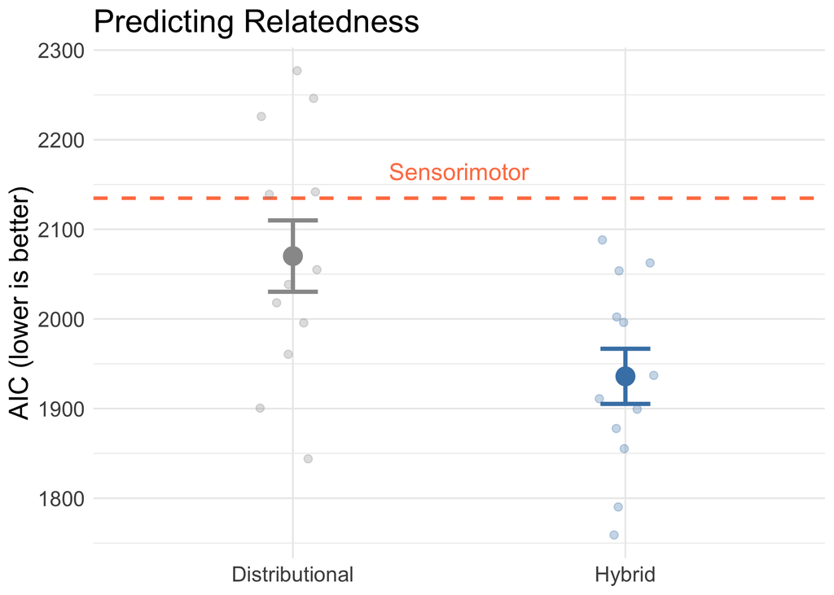

```r
# Get sensorimotor baseline (should be the same for all models)
aic_sm_baseline <- aic_summary_full %>%
  filter(type == "Sensorimotor") %>%
  pull(aic) %>%
  unique()

# Filter to just distributional and hybrid
aic_summary_no_sm <- aic_summary_full %>%
  filter(type != "Sensorimotor")

aic_summary_se_no_sm <- aic_summary_no_sm %>%
  group_by(type) %>%
  summarize(
    mean_aic = mean(aic),
    se_aic = sd(aic) / sqrt(n())
  )

ggplot() +
  # Sensorimotor baseline as dashed line
  geom_hline(yintercept = aic_sm_baseline,
             linetype = "dashed", color = "coral", linewidth = 1) +
  # Raw points for each model/layer
  geom_jitter(data = aic_summary_no_sm,
              aes(x = type, y = aic, color = type),
              alpha = 0.3, width = 0.1, size = 2) +
  # Mean + SE
  geom_point(data = aic_summary_se_no_sm,
             aes(x = type, y = mean_aic, color = type),
             size = 5) +
  geom_errorbar(data = aic_summary_se_no_sm,
                aes(x = type, ymin = mean_aic - se_aic,
                    ymax = mean_aic + se_aic, color = type),
                width = 0.15, linewidth = 1.2) +
  annotate("text", x = 1.5, y = aic_sm_baseline + 30,
           label = "Sensorimotor", color = "coral", size = 5)+
  labs(x = NULL,
       y = "AIC (lower is better)",
       title = "Predicting Relatedness") +
  scale_color_manual(values = c("Distributional" = "gray60",
                                "Hybrid" = "steelblue")) +
  theme_minimal() +
  theme(text = element_text(size = 16),
        legend.position = "none")
```

## Correlation between sensorimotor and distributional distance

```r
# Get best layer
df_by_layer = df_merged %>%
  group_by(Model, Multilingual, Layer, n_params) %>%
  summarise(r = cor(mean_relatedness, Distance, method = "pearson"),
            r2 = r ** 2,
            rho = cor(mean_relatedness, Distance, method = "spearman"),
            count = n())
```

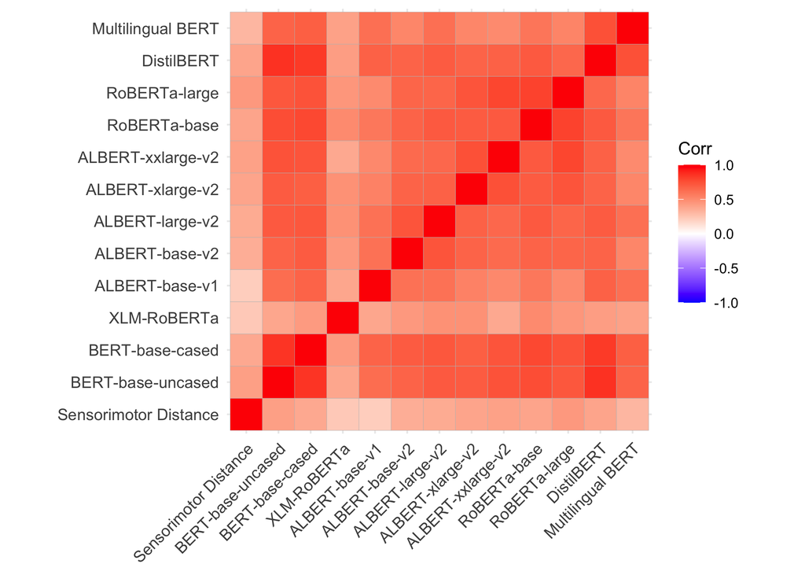

```r
df_best_layer <- df_by_layer %>%
  group_by(Model) %>%
  slice_max(r2, n = 1) %>%
  select(Model, Layer, r2)

# Filter for only best layers
df_best <- df_merged %>%
  semi_join(df_best_layer, by = c("Model", "Layer"))

# Pivot wider
df_wide <- df_best %>%
  mutate(`Sensorimotor Distance` = sensorimotor_distance) %>%
  select(word, sentence1, sentence2, `Sensorimotor Distance`, Model, Distance) %>%
  pivot_wider(names_from = Model, values_from = Distance)

# Compute correlation matrix
cor_matrix <- df_wide %>%
  select(`Sensorimotor Distance`, where(is.numeric)) %>%
  cor(use = "pairwise.complete.obs")

# Plot the correlation matrix
ggcorrplot(cor_matrix,
           hc.order = FALSE,
           method = "square") +
  theme(
    axis.text.x = element_text(size = 10, angle = 45, hjust = 1),
    axis.text.y = element_text(size = 10)
  )
```

# Baseline with LS Norms

```r
df_with_baseline = read_csv("../../data/processed/sentence_pairs_with_baseline.csv") %>%
  drop_na(sensorimotor_distance) %>%
  drop_na(baseline_distance)
nrow(df_with_baseline)
```

```
## [1] 576
```

## Does sensorimotor distance predict relatedness above the baseline?

We also ask whether whether our measure of contextualized sensorimotor distance predicts relatedness above and beyond a baseline that simply considers the decontextualized Lancaster Sensorimotor Norms for the dismabiguating words in a sentence. (We find that it does.)

```r
model_bow_sm  = lmer(data = df_with_baseline,
                mean_relatedness ~ baseline_distance + sensorimotor_distance +
                  (1| word),
                REML = FALSE)

model_just_bow  = lmer(data = df_with_baseline,
                mean_relatedness ~ baseline_distance +
                  (1| word),
                REML = FALSE)

model_just_sm  = lmer(data = df_with_baseline,
                mean_relatedness ~ sensorimotor_distance +
                  (1| word),
                REML = FALSE)

summary(model_bow_sm)
```

```
## Linear mixed model fit by maximum likelihood . t-tests use Satterthwaite's
##   method [lmerModLmerTest]
## Formula: mean_relatedness ~ baseline_distance + sensorimotor_distance +
##     (1 | word)
##    Data: df_with_baseline
##
##       AIC       BIC    logLik -2*log(L)  df.resid
##    1769.7    1791.4    -879.8    1759.7       571
##
## Scaled residuals:
##      Min       1Q   Median       3Q      Max
## -2.25085 -0.78889 -0.03104  0.72182  2.32643
##
## Random effects:
##  Groups   Name        Variance Std.Dev.
##  word     (Intercept) 0.3784   0.6152
##  Residual             1.0144   1.0072
## Number of obs: 576, groups:  word, 111
##
## Fixed effects:
##                       Estimate Std. Error       df t value Pr(>|t|)
## (Intercept)             3.2956     0.1052 275.9319  31.318  < 2e-16 ***
## baseline_distance      -2.2025     0.4063 574.4962  -5.421 8.73e-08 ***
## sensorimotor_distance -10.3560     0.8134 562.8948 -12.731  < 2e-16 ***
## ---
## Signif. codes:  0 '***' 0.001 '**' 0.01 '*' 0.05 '.' 0.1 ' ' 1
##
## Correlation of Fixed Effects:
##             (Intr) bsln_d
## basln_dstnc -0.455
## snsrmtr_dst -0.322 -0.411
```

```r
anova(model_bow_sm, model_just_bow)
```

```
## Data: df_with_baseline
## Models:
## model_just_bow: mean_relatedness ~ baseline_distance + (1 | word)
## model_bow_sm: mean_relatedness ~ baseline_distance + sensorimotor_distance + (1 | word)
##                npar    AIC    BIC  logLik -2*log(L)  Chisq Df Pr(>Chisq)
## model_just_bow    4 1909.7 1927.2 -950.86    1901.7
## model_bow_sm      5 1769.7 1791.4 -879.83    1759.7 142.07  1  < 2.2e-16 ***
## ---
## Signif. codes:  0 '***' 0.001 '**' 0.01 '*' 0.05 '.' 0.1 ' ' 1
```

```r
anova(model_bow_sm, model_just_sm)
```

```
## Data: df_with_baseline
## Models:
## model_just_sm: mean_relatedness ~ sensorimotor_distance + (1 | word)
## model_bow_sm: mean_relatedness ~ baseline_distance + sensorimotor_distance + (1 | word)
##               npar    AIC    BIC  logLik -2*log(L)  Chisq Df Pr(>Chisq)
## model_just_sm    4 1795.5 1813.0 -893.77    1787.5
## model_bow_sm     5 1769.7 1791.4 -879.83    1759.7 27.881  1   1.29e-07 ***
## ---
## Signif. codes:  0 '***' 0.001 '**' 0.01 '*' 0.05 '.' 0.1 ' ' 1
```

# Predicting Trott & Bergen (2023)

Here, we also ask whether sensorimotor distance can account for variance in RT and accuracy on a primed sensibility judgment task.

```r
# ============================================================
# Load T&B 2023 data and merge with norms
# ============================================================

df_s1 <- read_csv("../../data/tb2023/polysemy_s1_final.csv")
df_s2 <- read_csv("../../data/tb2023/polysemy_s2_final.csv")
df_tb2023 <- bind_rows(df_s1, df_s2)
nrow(df_tb2023)
```

```
## [1] 19828
```

```r
# Item-level aggregates
df_tb2023_agg_acc <- df_tb2023 %>%
  group_by(word, same, version) %>%
  summarise(accuracy = mean(correct_response), .groups = "drop")

df_tb2023_agg_rt <- df_tb2023 %>%
  filter(correct_response == TRUE) %>%
  group_by(word, same, version) %>%
  summarise(mean_rt = mean(rt), .groups = "drop") %>%
  mutate(mean_log_rt = log10(mean_rt))

# Merge with sensorimotor norms (for Part 1)
df_sm_acc <- df_rawc_with_norms %>%
  select(word, same, version, sensorimotor_distance,
         action_distance, perceptual_distance) %>%
  inner_join(df_tb2023_agg_acc, by = c("word", "same", "version"))

df_sm_rt <- df_rawc_with_norms %>%
  select(word, same, version, sensorimotor_distance,
         action_distance, perceptual_distance) %>%
  inner_join(df_tb2023_agg_rt, by = c("word", "same", "version"))

# Merge with full distributional sweep (for Part 2)
df_full_acc <- df_merged %>%
  inner_join(df_tb2023_agg_acc, by = c("word", "same", "version"))

df_full_rt <- df_merged %>%
  inner_join(df_tb2023_agg_rt, by = c("word", "same", "version"))

# Sanity check
nrow(df_sm_acc)
```

```
## [1] 624
```

```r
nrow(df_sm_rt)
```

```
## [1] 624
```

```r
nrow(df_full_acc)
```

```
## [1] 116064
```

```r
nrow(df_full_rt)
```

```
## [1] 116064
```

## Part 1: SM on its own

```r
mod_sm_acc = lmer(data = df_sm_acc,
                accuracy ~ sensorimotor_distance +
                  (1 | word))

summary(mod_sm_acc)
```

```
## Linear mixed model fit by REML. t-tests use Satterthwaite's method [
## lmerModLmerTest]
## Formula: accuracy ~ sensorimotor_distance + (1 | word)
##    Data: df_sm_acc
##
## REML criterion at convergence: -797.8
##
## Scaled residuals:
##     Min      1Q  Median      3Q     Max
## -3.3587 -0.5428  0.0906  0.5649  3.4823
##
## Random effects:
##  Groups   Name        Variance Std.Dev.
##  word     (Intercept) 0.01209  0.1100
##  Residual             0.01156  0.1075
## Number of obs: 624, groups:  word, 104
##
## Fixed effects:
##                        Estimate Std. Error        df t value Pr(>|t|)
## (Intercept)             0.87090    0.01331 164.87195  65.445  < 2e-16 ***
## sensorimotor_distance  -0.45734    0.08337 600.76283  -5.486 6.08e-08 ***
## ---
## Signif. codes:  0 '***' 0.001 '**' 0.01 '*' 0.05 '.' 0.1 ' ' 1
##
## Correlation of Fixed Effects:
##             (Intr)
## snsrmtr_dst -0.489
```

```r
mod_sm_rt = lmer(data = df_sm_rt,
                mean_log_rt ~ sensorimotor_distance +
                  (1 | word))

summary(mod_sm_rt)
```

```
## Linear mixed model fit by REML. t-tests use Satterthwaite's method [
## lmerModLmerTest]
## Formula: mean_log_rt ~ sensorimotor_distance + (1 | word)
##    Data: df_sm_rt
##
## REML criterion at convergence: -1626
##
## Scaled residuals:
##     Min      1Q  Median      3Q     Max
## -2.3618 -0.6298 -0.0177  0.5529  9.4863
##
## Random effects:
##  Groups   Name        Variance Std.Dev.
##  word     (Intercept) 0.001285 0.03584
##  Residual             0.003496 0.05912
## Number of obs: 624, groups:  word, 104
##
## Fixed effects:
##                        Estimate Std. Error        df t value Pr(>|t|)
## (Intercept)           3.040e+00  5.419e-03 2.085e+02 561.066  < 2e-16 ***
## sensorimotor_distance 2.272e-01  4.330e-02 6.184e+02   5.247 2.13e-07 ***
## ---
## Signif. codes:  0 '***' 0.001 '**' 0.01 '*' 0.05 '.' 0.1 ' ' 1
##
## Correlation of Fixed Effects:
##             (Intr)
## snsrmtr_dst -0.623
```

## Part 2: Comopare to distributional distance

```r
# --- Compute AIC for each model/layer: SM, Distributional, Hybrid ---

tb_acc_results <- df_full_acc %>%
  group_by(Model, Layer, n_params, Multilingual) %>%
  summarize(
    r2_sm       = summary(lm(accuracy ~ sensorimotor_distance))$r.squared,
    aic_sm      = AIC(lm(accuracy ~ sensorimotor_distance)),
    r2_bert     = summary(lm(accuracy ~ Distance))$r.squared,
    aic_bert    = AIC(lm(accuracy ~ Distance)),
    r2_combined = summary(lm(accuracy ~ Distance + sensorimotor_distance))$r.squared,
    aic_combined = AIC(lm(accuracy ~ Distance + sensorimotor_distance)),
    .groups = "drop"
  ) %>%
  mutate(
    aic_bert_vs_sm       = aic_bert - aic_sm,
    aic_combined_vs_sm   = aic_sm - aic_combined,
    aic_combined_vs_dist = aic_bert - aic_combined
  )

tb_rt_results <- df_full_rt %>%
  group_by(Model, Layer, n_params, Multilingual) %>%
  summarize(
    r2_sm       = summary(lm(mean_log_rt ~ sensorimotor_distance))$r.squared,
    aic_sm      = AIC(lm(mean_log_rt ~ sensorimotor_distance)),
    r2_bert     = summary(lm(mean_log_rt ~ Distance))$r.squared,
    aic_bert    = AIC(lm(mean_log_rt ~ Distance)),
    r2_combined = summary(lm(mean_log_rt ~ Distance + sensorimotor_distance))$r.squared,
    aic_combined = AIC(lm(mean_log_rt ~ Distance + sensorimotor_distance)),
    .groups = "drop"
  ) %>%
  mutate(
    aic_bert_vs_sm       = aic_bert - aic_sm,
    aic_combined_vs_sm   = aic_sm - aic_combined,
    aic_combined_vs_dist = aic_bert - aic_combined
  )

# --- Best layer per model (selected by best distributional R²) ---

best_layers_acc <- tb_acc_results %>%
  group_by(Model, n_params, Multilingual) %>%
  slice_max(r2_bert, n = 1) %>%
  ungroup()

best_layers_rt <- tb_rt_results %>%
  group_by(Model, n_params, Multilingual) %>%
  slice_max(r2_bert, n = 1) %>%
  ungroup()

print(best_layers_acc)
```

```
## # A tibble: 12 × 13
##    Model  Layer n_params Multilingual  r2_sm aic_sm r2_bert aic_bert r2_combined
##    <chr>  <dbl>    <dbl> <chr>         <dbl>  <dbl>   <dbl>    <dbl>       <dbl>
##  1 ALBER…    10   1.17e7 Monolingual  0.0242  -565. 0.00993    -556.      0.0287
##  2 ALBER…    10   1.17e7 Monolingual  0.0242  -565. 0.0390     -574.      0.0487
##  3 ALBER…    21   1.77e7 Monolingual  0.0242  -565. 0.0660     -592.      0.0720
##  4 ALBER…    19   5.87e7 Monolingual  0.0242  -565. 0.0907     -609.      0.0970
##  5 ALBER…    11   2.23e8 Monolingual  0.0242  -565. 0.0904     -609.      0.0931
##  6 BERT-…    12   1.08e8 Monolingual  0.0242  -565. 0.0289     -568.      0.0388
##  7 BERT-…     1   1.09e8 Monolingual  0.0242  -565. 0.0466     -579.      0.0895
##  8 Disti…     1   6.64e7 Monolingual  0.0242  -565. 0.0371     -573.      0.0776
##  9 Multi…     1   1.78e8 Multilingual 0.0242  -565. 0.0130     -558.      0.0394
## 10 RoBER…    12   1.25e8 Monolingual  0.0242  -565. 0.0558     -585.      0.0627
## 11 RoBER…    23   3.55e8 Monolingual  0.0242  -565. 0.0796     -601.      0.0815
## 12 XLM-R…     2   2.78e8 Multilingual 0.0242  -565. 0.0322     -570.      0.0553
## # ℹ 4 more variables: aic_combined <dbl>, aic_bert_vs_sm <dbl>,
## #   aic_combined_vs_sm <dbl>, aic_combined_vs_dist <dbl>
```

```r
print(best_layers_rt)
```

```
## # A tibble: 12 × 13
##    Model  Layer n_params Multilingual  r2_sm aic_sm r2_bert aic_bert r2_combined
##    <chr>  <dbl>    <dbl> <chr>         <dbl>  <dbl>   <dbl>    <dbl>       <dbl>
##  1 ALBER…     1   1.17e7 Monolingual  0.0303 -1562.  0.0645   -1584.      0.0867
##  2 ALBER…    12   1.17e7 Monolingual  0.0303 -1562.  0.0725   -1589.      0.0806
##  3 ALBER…    21   1.77e7 Monolingual  0.0303 -1562.  0.0774   -1593.      0.0853
##  4 ALBER…    16   5.87e7 Monolingual  0.0303 -1562.  0.0879   -1600.      0.0940
##  5 ALBER…     9   2.23e8 Monolingual  0.0303 -1562.  0.107    -1613.      0.110
##  6 BERT-…     0   1.08e8 Monolingual  0.0303 -1562.  0.0477   -1573.      0.0810
##  7 BERT-…     8   1.09e8 Monolingual  0.0303 -1562.  0.0515   -1575.      0.0613
##  8 Disti…     0   6.64e7 Monolingual  0.0303 -1562.  0.0484   -1573.      0.0838
##  9 Multi…     0   1.78e8 Multilingual 0.0303 -1562.  0.0636   -1583.      0.103
## 10 RoBER…     9   1.25e8 Monolingual  0.0303 -1562.  0.0541   -1577.      0.0629
## 11 RoBER…    12   3.55e8 Monolingual  0.0303 -1562.  0.0970   -1606.      0.0996
## 12 XLM-R…     0   2.78e8 Multilingual 0.0303 -1562.  0.0303   -1562.      0.0603
## # ℹ 4 more variables: aic_combined <dbl>, aic_bert_vs_sm <dbl>,
## #   aic_combined_vs_sm <dbl>, aic_combined_vs_dist <dbl>
```

```r
# --- Summary counts ---

best_layers_acc %>%
  mutate(dist_better_than_sm     = aic_bert_vs_sm < -4,
         hybrid_better_than_sm   = aic_combined_vs_sm > 4,
         hybrid_better_than_dist = aic_combined_vs_dist > 4) %>%
  summarise(across(c(dist_better_than_sm,
                     hybrid_better_than_sm,
                     hybrid_better_than_dist), mean))
```

```
## # A tibble: 1 × 3
##   dist_better_than_sm hybrid_better_than_sm hybrid_better_than_dist
##                 <dbl>                 <dbl>                   <dbl>
## 1                0.75                 0.917                   0.583
```

```r
best_layers_rt %>%
  mutate(dist_better_than_sm     = aic_bert_vs_sm < -4,
         hybrid_better_than_sm   = aic_combined_vs_sm > 4,
         hybrid_better_than_dist = aic_combined_vs_dist > 4) %>%
  summarise(across(c(dist_better_than_sm,
                     hybrid_better_than_sm,
                     hybrid_better_than_dist), mean))
```

```
## # A tibble: 1 × 3
##   dist_better_than_sm hybrid_better_than_sm hybrid_better_than_dist
##                 <dbl>                 <dbl>                   <dbl>
## 1               0.917                     1                     0.5
```

```r
# --- LaTeX tables ---

best_layers_acc %>%
  select(Model, aic_bert, aic_combined) %>%
  mutate(across(starts_with("aic"), round)) %>%
  kbl(col.names = c("Model", "Distributional", "Hybrid"),
      format = "latex", booktabs = TRUE,
      caption = sprintf("AIC values for predicting accuracy (Trott \\& Bergen, 2023). AIC for Sensorimotor Distance alone was %.2f.",
                        unique(best_layers_acc$aic_sm)),
      label = "aic_tb_acc") %>%
  kable_styling(latex_options = "hold_position")
```

```r
best_layers_rt %>%
  select(Model, aic_bert, aic_combined) %>%
  mutate(across(starts_with("aic"), round)) %>%
  kbl(col.names = c("Model", "Distributional", "Hybrid"),
      format = "latex", booktabs = TRUE,
      caption = sprintf("AIC values for predicting log RT (Trott \\& Bergen, 2023). AIC for Sensorimotor Distance alone was %.2f.",
                        unique(best_layers_rt$aic_sm)),
      label = "aic_tb_rt") %>%
  kable_styling(latex_options = "hold_position")
```

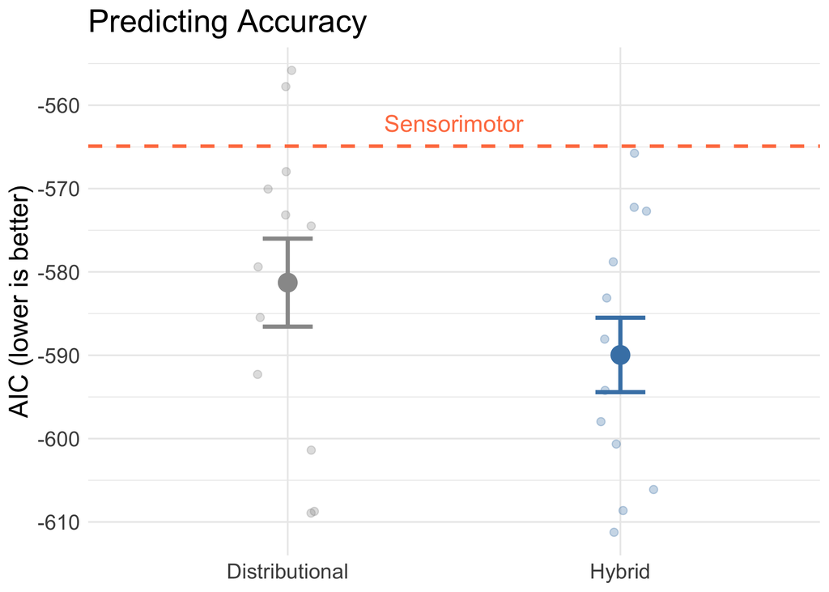

```r
# ============================================================
# Figures: AIC dot plots (matching your existing style)
# ============================================================

# --- Accuracy ---

aic_long_acc <- best_layers_acc %>%
  select(Model, Layer, aic_sm, aic_bert, aic_combined) %>%
  pivot_longer(cols = c(aic_sm, aic_bert, aic_combined),
               names_to = "type", values_to = "aic") %>%
  mutate(type = case_when(
    type == "aic_sm"       ~ "Sensorimotor",
    type == "aic_bert"     ~ "Distributional",
    type == "aic_combined" ~ "Hybrid"
  ),
  type = factor(type, levels = c("Sensorimotor", "Distributional", "Hybrid")))

baseline_acc <- aic_long_acc %>% filter(type == "Sensorimotor") %>% pull(aic) %>% unique()

aic_long_acc_no_sm <- aic_long_acc %>% filter(type != "Sensorimotor")

aic_se_acc <- aic_long_acc_no_sm %>%
  group_by(type) %>%
  summarize(mean_aic = mean(aic),
            se_aic = sd(aic) / sqrt(n()),
            .groups = "drop")

# Dynamic offset for the label (5% of y-range above baseline)
offset_acc <- diff(range(aic_long_acc_no_sm$aic)) * 0.05

ggplot() +
  geom_hline(yintercept = baseline_acc,
             linetype = "dashed", color = "coral", linewidth = 1) +
  geom_jitter(data = aic_long_acc_no_sm,
              aes(x = type, y = aic, color = type),
              alpha = 0.3, width = 0.1, size = 2) +
  geom_point(data = aic_se_acc,
             aes(x = type, y = mean_aic, color = type),
             size = 5) +
  geom_errorbar(data = aic_se_acc,
                aes(x = type, ymin = mean_aic - se_aic,
                    ymax = mean_aic + se_aic, color = type),
                width = 0.15, linewidth = 1.2) +
  annotate("text", x = 1.5, y = baseline_acc + offset_acc,
           label = "Sensorimotor", color = "coral", size = 5) +
  labs(x = NULL, y = "AIC (lower is better)",
       title = "Predicting Accuracy") +
  scale_color_manual(values = c("Distributional" = "gray60",
                                "Hybrid" = "steelblue")) +
  theme_minimal() +
  theme(text = element_text(size = 16), legend.position = "none")
```

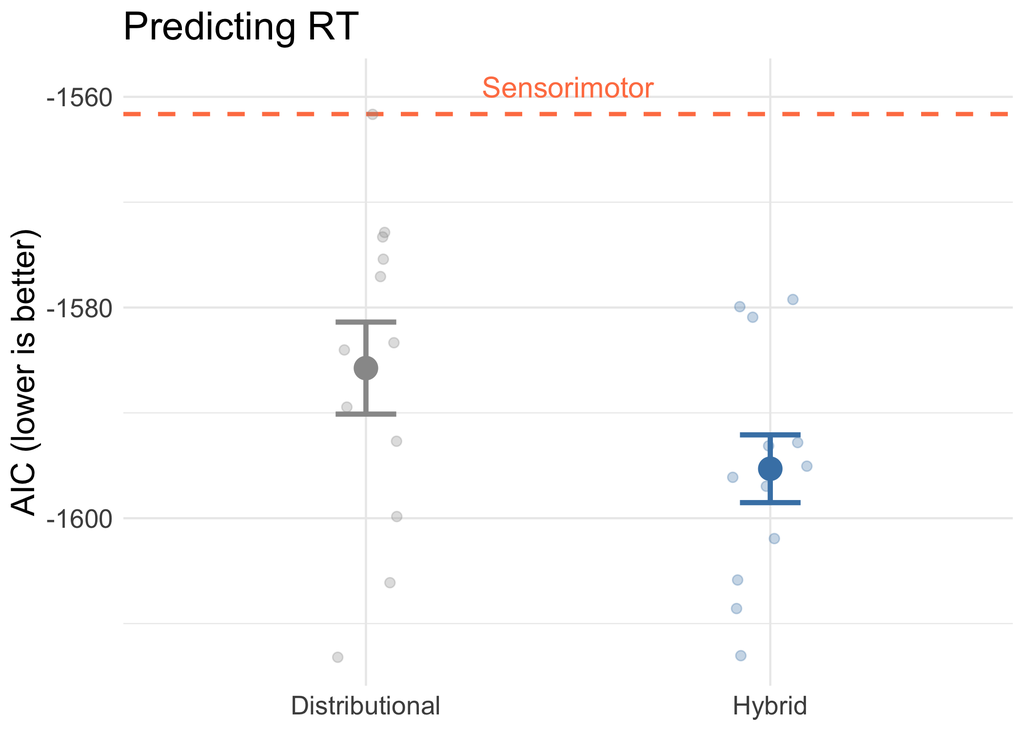

```r
# --- RT ---

aic_long_rt <- best_layers_rt %>%
  select(Model, Layer, aic_sm, aic_bert, aic_combined) %>%
  pivot_longer(cols = c(aic_sm, aic_bert, aic_combined),
               names_to = "type", values_to = "aic") %>%
  mutate(type = case_when(
    type == "aic_sm"       ~ "Sensorimotor",
    type == "aic_bert"     ~ "Distributional",
    type == "aic_combined" ~ "Hybrid"
  ),
  type = factor(type, levels = c("Sensorimotor", "Distributional", "Hybrid")))

baseline_rt <- aic_long_rt %>% filter(type == "Sensorimotor") %>% pull(aic) %>% unique()

aic_long_rt_no_sm <- aic_long_rt %>% filter(type != "Sensorimotor")

aic_se_rt <- aic_long_rt_no_sm %>%
  group_by(type) %>%
  summarize(mean_aic = mean(aic),
            se_aic = sd(aic) / sqrt(n()),
            .groups = "drop")

offset_rt <- diff(range(aic_long_rt_no_sm$aic)) * 0.05

ggplot() +
  geom_hline(yintercept = baseline_rt,
             linetype = "dashed", color = "coral", linewidth = 1) +
  geom_jitter(data = aic_long_rt_no_sm,
              aes(x = type, y = aic, color = type),
              alpha = 0.3, width = 0.1, size = 2) +
  geom_point(data = aic_se_rt,
             aes(x = type, y = mean_aic, color = type),
             size = 5) +
  geom_errorbar(data = aic_se_rt,
                aes(x = type, ymin = mean_aic - se_aic,
                    ymax = mean_aic + se_aic, color = type),
                width = 0.15, linewidth = 1.2) +
  annotate("text", x = 1.5, y = baseline_rt + offset_rt,
           label = "Sensorimotor", color = "coral", size = 5) +
  labs(x = NULL, y = "AIC (lower is better)",
       title = "Predicting RT") +
  scale_color_manual(values = c("Distributional" = "gray60",
                                "Hybrid" = "steelblue")) +
  theme_minimal() +
  theme(text = element_text(size = 16), legend.position = "none")
```

## Part 3: Does SM account for sense boundaries?

```r
# --- Compute AIC for each model/layer: same alone vs. same + continuous ---

tb_acc_q3 <- df_full_acc %>%
  group_by(Model, Layer, n_params, Multilingual) %>%
  summarize(
    aic_same      = AIC(lm(accuracy ~ same)),
    aic_same_sm   = AIC(lm(accuracy ~ same + sensorimotor_distance)),
    aic_same_dist = AIC(lm(accuracy ~ same + Distance)),
    aic_same_both = AIC(lm(accuracy ~ same + Distance + sensorimotor_distance)),
    r2_same_dist  = summary(lm(accuracy ~ same + Distance))$r.squared,
    .groups = "drop"
  ) %>%
  mutate(
    delta_aic_sm   = aic_same - aic_same_sm,    # positive = SM adds over same
    delta_aic_dist = aic_same - aic_same_dist,  # positive = Distributional adds over same
    delta_aic_both = aic_same - aic_same_both   # positive = both add over same
  )

tb_rt_q3 <- df_full_rt %>%
  group_by(Model, Layer, n_params, Multilingual) %>%
  summarize(
    aic_same      = AIC(lm(mean_log_rt ~ same)),
    aic_same_sm   = AIC(lm(mean_log_rt ~ same + sensorimotor_distance)),
    aic_same_dist = AIC(lm(mean_log_rt ~ same + Distance)),
    aic_same_both = AIC(lm(mean_log_rt ~ same + Distance + sensorimotor_distance)),
    r2_same_dist  = summary(lm(mean_log_rt ~ same + Distance))$r.squared,
    .groups = "drop"
  ) %>%
  mutate(
    delta_aic_sm   = aic_same - aic_same_sm,
    delta_aic_dist = aic_same - aic_same_dist,
    delta_aic_both = aic_same - aic_same_both
  )

# --- Best layer per model (selected by best same + Distributional R²) ---

best_layers_acc_q3 <- tb_acc_q3 %>%
  group_by(Model, n_params, Multilingual) %>%
  slice_max(r2_same_dist, n = 1) %>%
  ungroup()

best_layers_rt_q3 <- tb_rt_q3 %>%
  group_by(Model, n_params, Multilingual) %>%
  slice_max(r2_same_dist, n = 1) %>%
  ungroup()

print(best_layers_acc_q3)
```

```
## # A tibble: 12 × 12
##    Model          Layer n_params Multilingual aic_same aic_same_sm aic_same_dist
##    <chr>          <dbl>    <dbl> <chr>           <dbl>       <dbl>         <dbl>
##  1 ALBERT-base-v1     3   1.17e7 Monolingual     -594.       -594.         -601.
##  2 ALBERT-base-v2     1   1.17e7 Monolingual     -594.       -594.         -618.
##  3 ALBERT-large-…    22   1.77e7 Monolingual     -594.       -594.         -610.
##  4 ALBERT-xlarge…     3   5.87e7 Monolingual     -594.       -594.         -623.
##  5 ALBERT-xxlarg…    11   2.23e8 Monolingual     -594.       -594.         -613.
##  6 BERT-base-cas…     2   1.08e8 Monolingual     -594.       -594.         -628.
##  7 BERT-base-unc…     1   1.09e8 Monolingual     -594.       -594.         -662.
##  8 DistilBERT         1   6.64e7 Monolingual     -594.       -594.         -647.
##  9 Multilingual …     1   1.78e8 Multilingual    -594.       -594.         -609.
## 10 RoBERTa-base       1   1.25e8 Monolingual     -594.       -594.         -623.
## 11 RoBERTa-large      4   3.55e8 Monolingual     -594.       -594.         -637.
## 12 XLM-RoBERTa        2   2.78e8 Multilingual    -594.       -594.         -619.
## # ℹ 5 more variables: aic_same_both <dbl>, r2_same_dist <dbl>,
## #   delta_aic_sm <dbl>, delta_aic_dist <dbl>, delta_aic_both <dbl>
```

```r
print(best_layers_rt_q3)
```

```
## # A tibble: 12 × 12
##    Model          Layer n_params Multilingual aic_same aic_same_sm aic_same_dist
##    <chr>          <dbl>    <dbl> <chr>           <dbl>       <dbl>         <dbl>
##  1 ALBERT-base-v1     1   1.17e7 Monolingual    -1586.      -1589.        -1615.
##  2 ALBERT-base-v2     0   1.17e7 Monolingual    -1586.      -1589.        -1612.
##  3 ALBERT-large-…     0   1.77e7 Monolingual    -1586.      -1589.        -1616.
##  4 ALBERT-xlarge…     0   5.87e7 Monolingual    -1586.      -1589.        -1619.
##  5 ALBERT-xxlarg…     0   2.23e8 Monolingual    -1586.      -1589.        -1623.
##  6 BERT-base-cas…     0   1.08e8 Monolingual    -1586.      -1589.        -1614.
##  7 BERT-base-unc…     0   1.09e8 Monolingual    -1586.      -1589.        -1617.
##  8 DistilBERT         0   6.64e7 Monolingual    -1586.      -1589.        -1616.
##  9 Multilingual …     0   1.78e8 Multilingual   -1586.      -1589.        -1624.
## 10 RoBERTa-base       0   1.25e8 Monolingual    -1586.      -1589.        -1620.
## 11 RoBERTa-large      0   3.55e8 Monolingual    -1586.      -1589.        -1629.
## 12 XLM-RoBERTa        0   2.78e8 Multilingual   -1586.      -1589.        -1606.
## # ℹ 5 more variables: aic_same_both <dbl>, r2_same_dist <dbl>,
## #   delta_aic_sm <dbl>, delta_aic_dist <dbl>, delta_aic_both <dbl>
```

```r
# --- Summary counts: how often does each augmentation add over same alone ---

best_layers_acc_q3 %>%
  mutate(sm_adds   = delta_aic_sm > 4,
         dist_adds = delta_aic_dist > 4,
         both_add  = delta_aic_both > 4) %>%
  summarise(across(c(sm_adds, dist_adds, both_add), mean))
```

```
## # A tibble: 1 × 3
##   sm_adds dist_adds both_add
##     <dbl>     <dbl>    <dbl>
## 1       0         1        1
```

```r
best_layers_rt_q3 %>%
  mutate(sm_adds   = delta_aic_sm > 4,
         dist_adds = delta_aic_dist > 4,
         both_add  = delta_aic_both > 4) %>%
  summarise(across(c(sm_adds, dist_adds, both_add), mean))
```

```
## # A tibble: 1 × 3
##   sm_adds dist_adds both_add
##     <dbl>     <dbl>    <dbl>
## 1       0         1        1
```

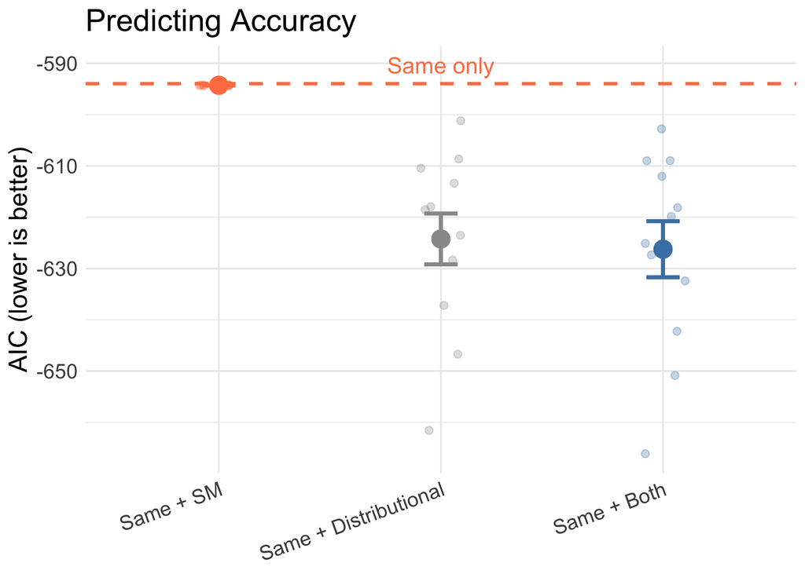

```r
make_aic_plot_q3 <- function(best_layers_df, title) {
  aic_long <- best_layers_df %>%
    select(Model, Layer, aic_same, aic_same_sm, aic_same_dist, aic_same_both) %>%
    pivot_longer(cols = c(aic_same, aic_same_sm, aic_same_dist, aic_same_both),
                 names_to = "type", values_to = "aic") %>%
    mutate(type = case_when(
      type == "aic_same"      ~ "Same only",
      type == "aic_same_sm"   ~ "Same + SM",
      type == "aic_same_dist" ~ "Same + Distributional",
      type == "aic_same_both" ~ "Same + Both"
    ),
    type = factor(type, levels = c("Same only", "Same + SM",
                                    "Same + Distributional", "Same + Both")))

  baseline <- aic_long %>% filter(type == "Same only") %>% pull(aic) %>% unique()

  aic_long_no_base <- aic_long %>% filter(type != "Same only")

  aic_se <- aic_long_no_base %>%
    group_by(type) %>%
    summarize(mean_aic = mean(aic),
              se_aic = sd(aic) / sqrt(n()),
              .groups = "drop")

  offset <- diff(range(aic_long_no_base$aic)) * 0.05

  ggplot() +
    geom_hline(yintercept = baseline,
               linetype = "dashed", color = "coral", linewidth = 1) +
    geom_jitter(data = aic_long_no_base,
                aes(x = type, y = aic, color = type),
                alpha = 0.3, width = 0.1, size = 2) +
    geom_point(data = aic_se,
               aes(x = type, y = mean_aic, color = type),
               size = 5) +
    geom_errorbar(data = aic_se,
                  aes(x = type, ymin = mean_aic - se_aic,
                      ymax = mean_aic + se_aic, color = type),
                  width = 0.15, linewidth = 1.2) +
    annotate("text", x = 2, y = baseline + offset,
             label = "Same only", color = "coral", size = 5) +
    labs(x = NULL, y = "AIC (lower is better)", title = title) +
    scale_color_manual(values = c("Same + SM" = "coral",
                                  "Same + Distributional" = "gray60",
                                  "Same + Both" = "steelblue")) +
    theme_minimal() +
    theme(text = element_text(size = 16), legend.position = "none",
          axis.text.x = element_text(angle = 20, hjust = 1))
}

make_aic_plot_q3(best_layers_acc_q3, "Predicting Accuracy")
```

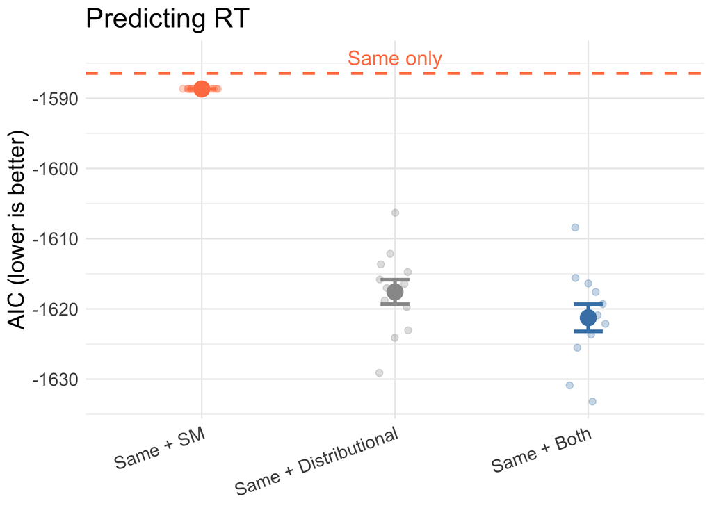

```r
make_aic_plot_q3(best_layers_rt_q3, "Predicting RT")
```

# Comparison to Trott (2024) LLM Norms

Here, we conduct a more in-depth comparison to the GPT-4-generated norms from Trott (2024).

## Load data

```r
df_gpt_perception = read_csv("../../data/trott2024/cs_norms_perception_gpt-4.csv")
df_gpt_action = read_csv("../../data/trott2024/cs_norms_action_gpt-4.csv")
df_both_gpt = df_gpt_perception %>%
  inner_join(df_gpt_action)
df_gpt_with_human = df_both_gpt %>%
  inner_join(df_contextualized_meanings)
### RAW-C With GPT and human SM distance
df_rawc_with_sm = read_csv("../../data/trott2024/rawc_with_sm.csv")
```

## Dimension-level correlation

```r
df_summ = df_gpt_with_human %>%
  summarise(Vision = cor(Vision.M, Vision, method = "spearman"),
            Hearing = cor(Hearing.M, Hearing, method = "spearman"),
            Touch = cor(Touch.M, Touch, method = "spearman"),
            Olfaction = cor(Olfaction.M, Olfaction, method = "spearman"),
            Taste = cor(Taste.M, Taste, method = "spearman"),
            Interoception = cor(Interoception.M, Interoception, method = "spearman"),
            Hand_arm = cor(Hand_arm.M, Hand_arm, method = "spearman"),
            Foot_leg = cor(Foot_leg.M, Foot_leg, method = "spearman"),
            Head = cor(Head.M, Head, method = "spearman"),
            Torso = cor(Torso.M, Torso, method = "spearman"),
            Mouth_throat = cor(Mouth_throat.M, Mouth_throat, method = "spearman"))

df_summ
```

```
## # A tibble: 1 × 11
##   Vision Hearing Touch Olfaction Taste Interoception Hand_arm Foot_leg  Head
##    <dbl>   <dbl> <dbl>     <dbl> <dbl>         <dbl>    <dbl>    <dbl> <dbl>
## 1  0.663   0.662 0.750     0.708 0.626         0.545    0.640    0.564 0.447
## # ℹ 2 more variables: Torso <dbl>, Mouth_throat <dbl>
```

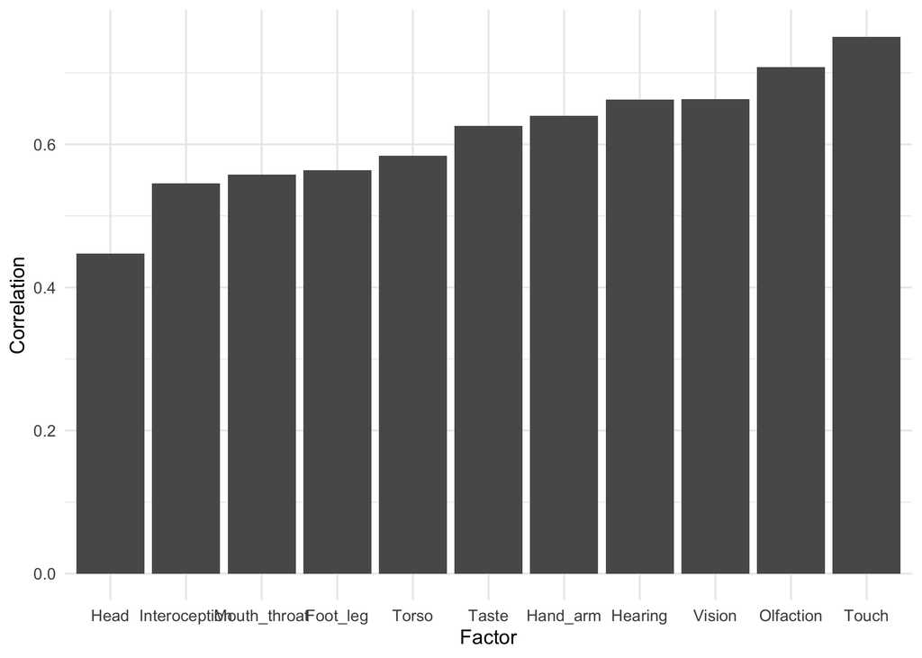

```r
df_long = df_summ %>%
  pivot_longer(everything(), names_to = "Factor", values_to = "Correlation")

df_long %>%
  ggplot(aes(x = reorder(Factor, Correlation), y = Correlation)) +
  geom_bar(stat = "identity") +
  labs(x = "Factor", y = "Correlation") +
  theme_minimal()
```

## Compare correlation matrices

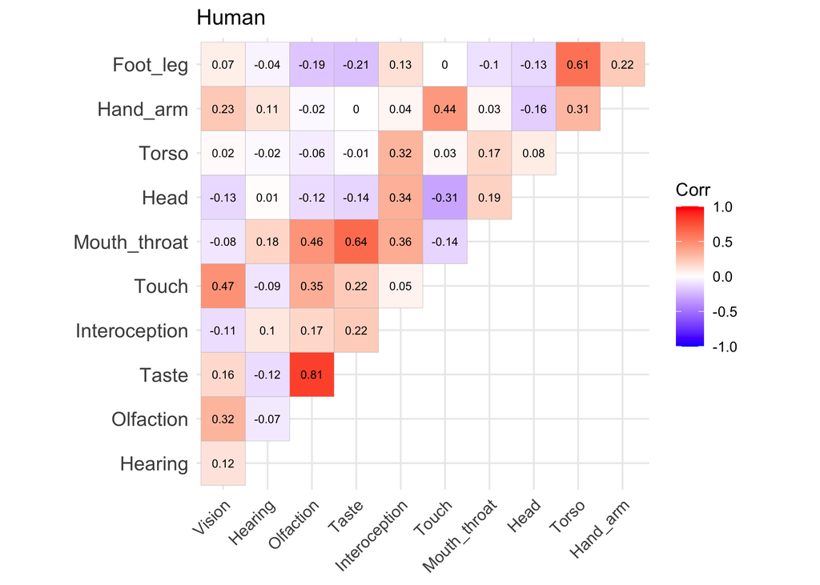

```r
library(tidyverse)
library(ggcorrplot)
library(patchwork)

dim_order <- c("Vision", "Hearing", "Olfaction", "Taste", "Interoception",
               "Touch", "Mouth_throat", "Head", "Torso", "Hand_arm", "Foot_leg")

# Human matrix: .M columns
human_cols <- df_gpt_with_human %>%
  select(all_of(paste0(dim_order, ".M"))) %>%
  rename_with(~ str_remove(., "\\.M"))
cors_human <- cor(human_cols, use = "pairwise.complete.obs")

# GPT matrix: bare-named columns
gpt_cols <- df_gpt_with_human %>%
  select(all_of(dim_order))
cors_gpt <- cor(gpt_cols, use = "pairwise.complete.obs")

# Difference (GPT - Human)
cors_diff <- cors_gpt - cors_human

ggcorrplot(cors_human, hc.order = FALSE, type = "upper",
                      lab = TRUE, lab_size = 2.5) +
  ggtitle("Human") +
  theme(axis.text.x = element_text(size = 10, angle = 45, hjust = 1))
```

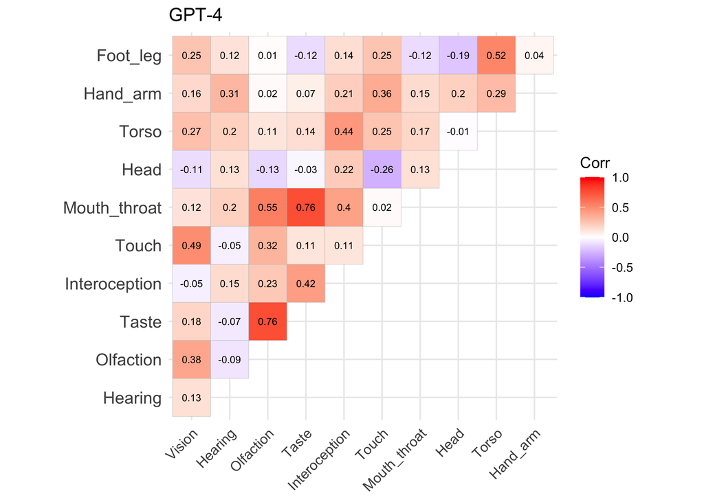

```r
ggcorrplot(cors_gpt, hc.order = FALSE, type = "upper",
                    lab = TRUE, lab_size = 2.5) +
  ggtitle("GPT-4") +
  theme(axis.text.x = element_text(size = 10, angle = 45, hjust = 1))
```

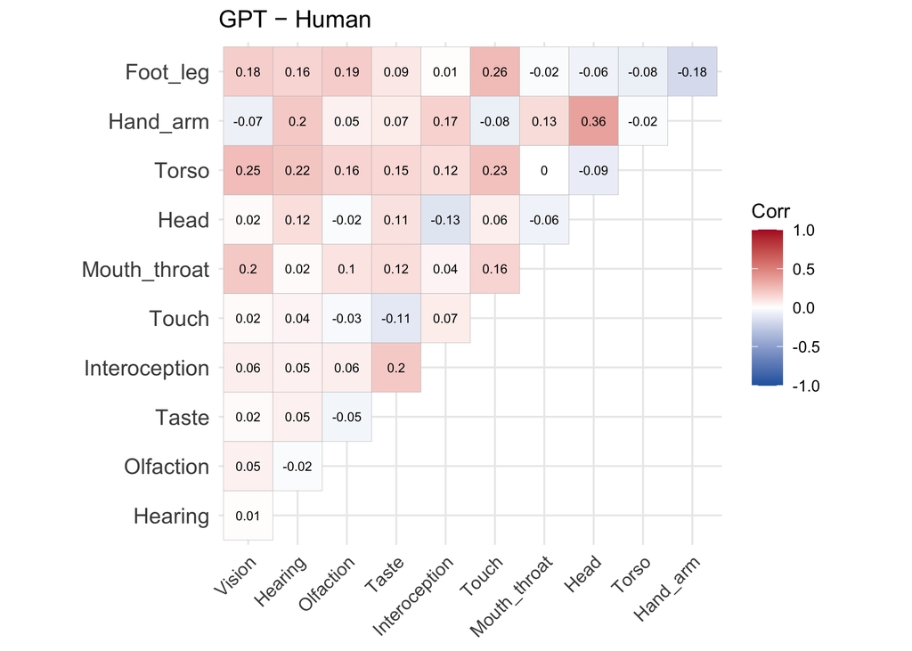

```r
ggcorrplot(cors_diff, hc.order = FALSE, type = "upper",
                     lab = TRUE, lab_size = 2.5,
                     colors = c("#2166AC", "white", "#B2182B")) +
  ggtitle("GPT − Human") +
  theme(axis.text.x = element_text(size = 10, angle = 45, hjust = 1))
```

```r
### Statistical comparison
library(vegan)
# Mantel test
mantel_result <- mantel(cors_human, cors_gpt,
                        method = "pearson",   # or "spearman"
                        permutations = 9999)

mantel_result
```

```
##
## Mantel statistic based on Pearson's product-moment correlation
##
## Call:
## mantel(xdis = cors_human, ydis = cors_gpt, method = "pearson",      permutations = 9999)
##
## Mantel statistic r: 0.8789
##       Significance: 1e-04
##
## Upper quantiles of permutations (null model):
##   90%   95% 97.5%   99%
## 0.178 0.230 0.283 0.344
## Permutation: free
## Number of permutations: 9999
```

```r
mantel_result <- mantel(cors_human, cors_gpt,
                        method = "spearman",   # or "spearman"
                        permutations = 9999)

mantel_result
```

```
##
## Mantel statistic based on Spearman's rank correlation rho
##
## Call:
## mantel(xdis = cors_human, ydis = cors_gpt, method = "spearman",      permutations = 9999)
##
## Mantel statistic r: 0.8142
##       Significance: 1e-04
##
## Upper quantiles of permutations (null model):
##   90%   95% 97.5%   99%
## 0.177 0.235 0.283 0.343
## Permutation: free
## Number of permutations: 9999
```

```r
## Or just straight-up correlation
upper_human <- cors_human[upper.tri(cors_human)]
upper_gpt   <- cors_gpt[upper.tri(cors_gpt)]

# Correlation between the two
cor(upper_human, upper_gpt, method = "pearson")
```

```
## [1] 0.8789399
```

```r
cor(upper_human, upper_gpt, method = "spearman")
```

```
## [1] 0.8142136
```

## Substitution analyses

### Homonymy vs. Polysemy

Here, we ask whether homonyms show bigger sensorimotor distance for GPT-generated norms as well.

```r
model_full = lmer(data = df_rawc_with_sm,
                  sm_gpt ~ same +
                    (1 + same | word),
                  control=lmerControl(optimizer="bobyqa"),
                  REML = FALSE)
```

```
## boundary (singular) fit: see help('isSingular')
```

```r
model_reduced = lmer(data = df_rawc_with_sm,
                  sm_gpt ~ # same +
                    (1 + same | word),
                  control=lmerControl(optimizer="bobyqa"),
                  REML = FALSE)

summary(model_full)
```

```
## Linear mixed model fit by maximum likelihood . t-tests use Satterthwaite's
##   method [lmerModLmerTest]
## Formula: sm_gpt ~ same + (1 + same | word)
##    Data: df_rawc_with_sm
## Control: lmerControl(optimizer = "bobyqa")
##
##       AIC       BIC    logLik -2*log(L)  df.resid
##   -1868.8   -1841.7     940.4   -1880.8       666
##
## Scaled residuals:
##     Min      1Q  Median      3Q     Max
## -3.3623 -0.4972 -0.1112  0.3717  4.2580
##
## Random effects:
##  Groups   Name        Variance Std.Dev. Corr
##  word     (Intercept) 0.008349 0.09137
##           sameTRUE    0.006232 0.07895  -1.00
##  Residual             0.002246 0.04739
## Number of obs: 672, groups:  word, 112
##
## Fixed effects:
##               Estimate Std. Error         df t value Pr(>|t|)
## (Intercept)   0.129956   0.008919 112.000265  14.570  < 2e-16 ***
## sameTRUE     -0.080311   0.008407 114.406843  -9.552 2.98e-16 ***
## ---
## Signif. codes:  0 '***' 0.001 '**' 0.01 '*' 0.05 '.' 0.1 ' ' 1
##
## Correlation of Fixed Effects:
##          (Intr)
## sameTRUE -0.926
## optimizer (bobyqa) convergence code: 0 (OK)
## boundary (singular) fit: see help('isSingular')
```

```r
anova(model_full, model_reduced)
```

```
## Data: df_rawc_with_sm
## Models:
## model_reduced: sm_gpt ~ (1 + same | word)
## model_full: sm_gpt ~ same + (1 + same | word)
##               npar     AIC     BIC logLik -2*log(L)  Chisq Df Pr(>Chisq)
## model_reduced    5 -1803.8 -1781.3 906.92   -1813.8
## model_full       6 -1868.8 -1841.7 940.38   -1880.8 66.912  1   2.84e-16 ***
## ---
## Signif. codes:  0 '***' 0.001 '**' 0.01 '*' 0.05 '.' 0.1 ' ' 1
```

```r
model_full_at = lmer(data = df_rawc_with_sm,
                  sm_gpt ~ same * ambiguity_type +
                    (1 + same | word),
                  control=lmerControl(optimizer="bobyqa"),
                  REML = FALSE)
```

```
## boundary (singular) fit: see help('isSingular')
```

```r
model_reduced_at = lmer(data = df_rawc_with_sm,
                  sm_gpt ~ same + ambiguity_type +
                    (1 + same | word),
                  control=lmerControl(optimizer="bobyqa"),
                  REML = FALSE)
```

```
## boundary (singular) fit: see help('isSingular')
```

```r
summary(model_full_at)
```

```
## Linear mixed model fit by maximum likelihood . t-tests use Satterthwaite's
##   method [lmerModLmerTest]
## Formula: sm_gpt ~ same * ambiguity_type + (1 + same | word)
##    Data: df_rawc_with_sm
## Control: lmerControl(optimizer = "bobyqa")
##
##       AIC       BIC    logLik -2*log(L)  df.resid
##   -1875.3   -1839.3     945.7   -1891.3       664
##
## Scaled residuals:
##     Min      1Q  Median      3Q     Max
## -3.3594 -0.4954 -0.0974  0.3721  4.3933
##
## Random effects:
##  Groups   Name        Variance Std.Dev. Corr
##  word     (Intercept) 0.007794 0.08829
##           sameTRUE    0.005588 0.07475  -1.00
##  Residual             0.002231 0.04724
## Number of obs: 672, groups:  word, 112
##
## Fixed effects:
##                                  Estimate Std. Error        df t value Pr(>|t|)
## (Intercept)                       0.16294    0.01483 112.00070  10.990  < 2e-16
## sameTRUE                         -0.11692    0.01382 114.97390  -8.458 9.86e-14
## ambiguity_typePolysemy           -0.04991    0.01824 112.00070  -2.737  0.00722
## sameTRUE:ambiguity_typePolysemy   0.05541    0.01701 114.97390   3.258  0.00147
##
## (Intercept)                     ***
## sameTRUE                        ***
## ambiguity_typePolysemy          **
## sameTRUE:ambiguity_typePolysemy **
## ---
## Signif. codes:  0 '***' 0.001 '**' 0.01 '*' 0.05 '.' 0.1 ' ' 1
##
## Correlation of Fixed Effects:
##             (Intr) smTRUE ambg_P
## sameTRUE    -0.919
## ambgty_typP -0.813  0.747
## smTRUE:mb_P  0.747 -0.813 -0.919
## optimizer (bobyqa) convergence code: 0 (OK)
## boundary (singular) fit: see help('isSingular')
```

```r
anova(model_full_at, model_reduced_at)
```

```
## Data: df_rawc_with_sm
## Models:
## model_reduced_at: sm_gpt ~ same + ambiguity_type + (1 + same | word)
## model_full_at: sm_gpt ~ same * ambiguity_type + (1 + same | word)
##                  npar     AIC     BIC logLik -2*log(L)  Chisq Df Pr(>Chisq)
## model_reduced_at    7 -1867.2 -1835.6 940.59   -1881.2
## model_full_at       8 -1875.3 -1839.3 945.67   -1891.3 10.154  1    0.00144 **
## ---
## Signif. codes:  0 '***' 0.001 '**' 0.01 '*' 0.05 '.' 0.1 ' ' 1
```

```r
df_rawc_with_sm %>%
  group_by(same, ambiguity_type) %>%
  summarise(mean_gpt = mean(sm_gpt),
            sd_gpt = sd(sm_gpt),
            mean_human = mean(sm_human),
            sd_human = sd(sm_human))
```

```
## # A tibble: 4 × 6
## # Groups:   same [2]
##   same  ambiguity_type mean_gpt sd_gpt mean_human sd_human
##   <lgl> <chr>             <dbl>  <dbl>      <dbl>    <dbl>
## 1 FALSE Homonymy         0.163  0.114      0.130    0.0806
## 2 FALSE Polysemy         0.113  0.0926     0.0849   0.0651
## 3 TRUE  Homonymy         0.0460 0.0518     0.0455   0.0314
## 4 TRUE  Polysemy         0.0515 0.0485     0.0420   0.0297
```

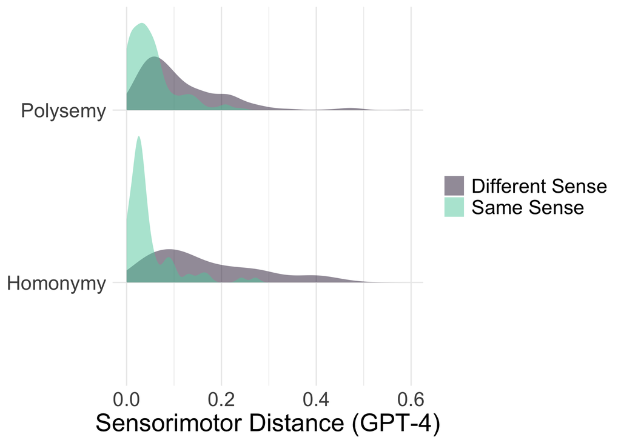

```r
df_rawc_with_sm = df_rawc_with_sm %>%
  mutate(Same = case_when(
    same == TRUE ~ "Same Sense",
    same == FALSE ~ "Different Sense"
  ))




df_rawc_with_sm %>%
  ggplot(aes(x = sm_gpt,
             y = ambiguity_type,
             fill = Same)) +
  geom_density_ridges2(aes(height = ..density..),
                       color = NA,
                       alpha = 0.5,
                       scale=0.85,
                       stat="density") +
  labs(x = "Sensorimotor Distance (GPT-4)",
       y = NULL,
       fill = NULL) +
  scale_fill_manual(
    values = c("Same Sense" = viridisLite::viridis(2, option = "mako", begin = 0.8, end = 0.15)[1],
               "Different Sense" = viridisLite::viridis(2, option = "mako", begin = 0.8, end = 0.15)[2])
  ) +
  theme_minimal() +
  theme(text = element_text(size = 20))
```

### Dominance

We also replicate the dominance analysis.

```r
df_dom_gpt = df_gpt_with_human %>%
  inner_join(df_dominance_individual)
df_dom_gpt <- df_dom_gpt %>%
  inner_join(df_lancaster)
nrow(df_dom_gpt)
```

```
## [1] 448
```

```r
df_dom_gpt = df_dom_gpt %>%
  rowwise() %>%
  mutate(max_strength_gpt = max(
    c(
      ## Modalities
      Vision,
      Hearing,
      Olfaction,
      Touch,
      Taste,
      Interoception,
      ## Effectors
      Head,
      Mouth_throat,
      Torso,
      Hand_arm,
      Foot_leg
    )
  ),
  minkowski3_strength_gpt = sum(c(Vision,
      Hearing,
      Olfaction,
      Touch,
      Taste,
      Interoception,
      ## Effectors
      Head,
      Mouth_throat,
      Torso,
      Hand_arm,
      Foot_leg)^3)^(1/3),
max_strength = max(
    c(
      ## Modalities
      Vision.M,
      Hearing.M,
      Olfaction.M,
      Touch.M,
      Taste.M,
      Interoception.M,
      ## Effectors
      Head.M,
      Mouth_throat.M,
      Torso.M,
      Hand_arm.M,
      Foot_leg.M
    )
  ),
  minkowski3_strength = sum(c(Vision.M, Hearing.M, Olfaction.M, Touch.M, Taste.M,
                               Interoception.M, Head.M, Mouth_throat.M, Torso.M,
                               Hand_arm.M, Foot_leg.M)^3)^(1/3)
  ) %>%
  ungroup()



cor.test(df_dom_gpt$max_strength_gpt, df_dom_gpt$max_strength)
```

```
##
##  Pearson's product-moment correlation
##
## data:  df_dom_gpt$max_strength_gpt and df_dom_gpt$max_strength
## t = 17.904, df = 446, p-value < 2.2e-16
## alternative hypothesis: true correlation is not equal to 0
## 95 percent confidence interval:
##  0.5893318 0.6975251
## sample estimates:
##       cor
## 0.6466694
```

```r
cor.test(df_dom_gpt$minkowski3_strength_gpt, df_dom_gpt$minkowski3_strength)
```

```
##
##  Pearson's product-moment correlation
##
## data:  df_dom_gpt$minkowski3_strength_gpt and df_dom_gpt$minkowski3_strength
## t = 20.683, df = 446, p-value < 2.2e-16
## alternative hypothesis: true correlation is not equal to 0
## 95 percent confidence interval:
##  0.6491292 0.7441050
## sample estimates:
##       cor
## 0.6996954
```

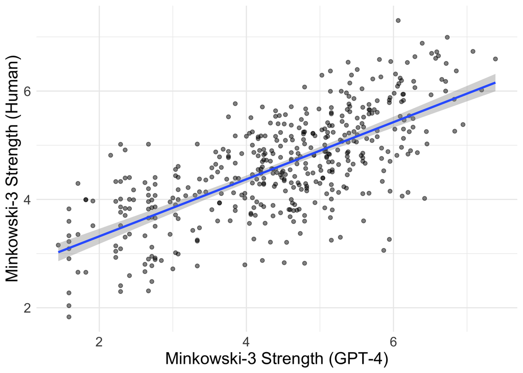

```r
df_dom_gpt %>%
  ggplot(aes(x = minkowski3_strength_gpt,
             y = minkowski3_strength)) +
  geom_point(alpha = .5) +
  geom_smooth(method = "lm") +
  labs(x = "Minkowski-3 Strength (GPT-4)",
       y = "Minkowski-3 Strength (Human)") +
  theme_minimal() +
  theme(text = element_text(size = 16), legend.position = "none")
```

### Does GPT sensorimotor strength predict dominance?

[figure not shown]

```r
df_dom_gpt %>%
  ggplot(aes(x = minkowski3_strength,
             y = dominance)) +
  geom_point(alpha = .4) +
  geom_smooth(method = "lm") +
  labs(x = "Minkowski-3 Sensorimotor Strength (GPT-4)",
       y = "Dominance") +
  theme_minimal() +
  theme(text = element_text(size=16))
```

```r
model_full = lmer(data = df_dom_gpt,
                dominance ~
                  max_strength_gpt +
                  Max_strength.sensorimotor + Minkowski3.sensorimotor +
                  (1 | word),
                REML = FALSE)
```

```
## boundary (singular) fit: see help('isSingular')
```

```r
model_reduced = lmer(data = df_dom_gpt,
                dominance ~
                  # max_strength_gpt +
                  Max_strength.sensorimotor + Minkowski3.sensorimotor +
                  (1 | word),
                REML = FALSE)
```

```
## boundary (singular) fit: see help('isSingular')
```

```r
summary(model_full)
```

```
## Linear mixed model fit by maximum likelihood . t-tests use Satterthwaite's
##   method [lmerModLmerTest]
## Formula:
## dominance ~ max_strength_gpt + Max_strength.sensorimotor + Minkowski3.sensorimotor +
##     (1 | word)
##    Data: df_dom_gpt
##
##       AIC       BIC    logLik -2*log(L)  df.resid
##    1087.5    1112.1    -537.7    1075.5       442
##
## Scaled residuals:
##      Min       1Q   Median       3Q      Max
## -2.39984 -0.77140 -0.03812  0.78786  2.40276
##
## Random effects:
##  Groups   Name        Variance Std.Dev.
##  word     (Intercept) 0.0000   0.0000
##  Residual             0.6458   0.8036
## Number of obs: 448, groups:  word, 112
##
## Fixed effects:
##                            Estimate Std. Error        df t value Pr(>|t|)
## (Intercept)                -0.15421    0.23863 448.00000  -0.646    0.518
## max_strength_gpt            0.05717    0.04481 448.00000   1.276    0.203
## Max_strength.sensorimotor   0.04113    0.11148 448.00000   0.369    0.712
## Minkowski3.sensorimotor    -0.06341    0.07370 448.00000  -0.860    0.390
##
## Correlation of Fixed Effects:
##             (Intr) mx_st_ Mx_st.
## mx_strngth_ -0.220
## Mx_strngth. -0.442 -0.146
## Mnkwsk3.sns -0.040 -0.101 -0.806
## optimizer (nloptwrap) convergence code: 0 (OK)
## boundary (singular) fit: see help('isSingular')
```

```r
anova(model_full, model_reduced)
```

```
## Data: df_dom_gpt
## Models:
## model_reduced: dominance ~ Max_strength.sensorimotor + Minkowski3.sensorimotor + (1 | word)
## model_full: dominance ~ max_strength_gpt + Max_strength.sensorimotor + Minkowski3.sensorimotor + (1 | word)
##               npar    AIC    BIC  logLik -2*log(L)  Chisq Df Pr(>Chisq)
## model_reduced    5 1087.1 1107.6 -538.54    1077.1
## model_full       6 1087.5 1112.1 -537.73    1075.5 1.6251  1     0.2024
```

```r
model_full = lmer(data = df_dom_gpt,
                dominance ~
                  minkowski3_strength_gpt +
                  Max_strength.sensorimotor + Minkowski3.sensorimotor +
                  (1 | word),
                REML = FALSE)
```

```
## boundary (singular) fit: see help('isSingular')
```

```r
model_reduced = lmer(data = df_dom_gpt,
                dominance ~
                  # minkowski3_strength_gpt +
                  Max_strength.sensorimotor + Minkowski3.sensorimotor +
                  (1 | word),
                REML = FALSE)
```

```
## boundary (singular) fit: see help('isSingular')
```

```r
summary(model_full)
```

```
## Linear mixed model fit by maximum likelihood . t-tests use Satterthwaite's
##   method [lmerModLmerTest]
## Formula: dominance ~ minkowski3_strength_gpt + Max_strength.sensorimotor +
##     Minkowski3.sensorimotor + (1 | word)
##    Data: df_dom_gpt
##
##       AIC       BIC    logLik -2*log(L)  df.resid
##    1083.2    1107.8    -535.6    1071.2       442
##
## Scaled residuals:
##     Min      1Q  Median      3Q     Max
## -2.3436 -0.7781 -0.0222  0.7803  2.3622
##
## Random effects:
##  Groups   Name        Variance Std.Dev.
##  word     (Intercept) 0.0000   0.0000
##  Residual             0.6397   0.7998
## Number of obs: 448, groups:  word, 112
##
## Fixed effects:
##                            Estimate Std. Error        df t value Pr(>|t|)
## (Intercept)                -0.18698    0.23528 448.00000  -0.795   0.4272
## minkowski3_strength_gpt     0.08110    0.03333 448.00000   2.433   0.0154 *
## Max_strength.sensorimotor   0.05806    0.10978 448.00000   0.529   0.5972
## Minkowski3.sensorimotor    -0.10444    0.07587 448.00000  -1.377   0.1693
## ---
## Signif. codes:  0 '***' 0.001 '**' 0.01 '*' 0.05 '.' 0.1 ' ' 1
##
## Correlation of Fixed Effects:
##             (Intr) mnk3__ Mx_st.
## mnkwsk3_st_ -0.174
## Mx_strngth. -0.481 -0.014
## Mnkwsk3.sns -0.013 -0.274 -0.798
## optimizer (nloptwrap) convergence code: 0 (OK)
## boundary (singular) fit: see help('isSingular')
```

```r
anova(model_full, model_reduced)
```

```
## Data: df_dom_gpt
## Models:
## model_reduced: dominance ~ Max_strength.sensorimotor + Minkowski3.sensorimotor + (1 | word)
## model_full: dominance ~ minkowski3_strength_gpt + Max_strength.sensorimotor + Minkowski3.sensorimotor + (1 | word)
##               npar    AIC    BIC  logLik -2*log(L)  Chisq Df Pr(>Chisq)
## model_reduced    5 1087.1 1107.6 -538.54    1077.1
## model_full       6 1083.2 1107.8 -535.60    1071.2 5.8807  1    0.01531 *
## ---
## Signif. codes:  0 '***' 0.001 '**' 0.01 '*' 0.05 '.' 0.1 ' ' 1
```